# R Assignment 4

Nina Dyatchenko

September 12th, 2018

## Assignment 4: Due Sunday, 16 September at 23:59PM

*For help with Rmarkdown for reports, see this [white paper](http://www.stat.cmu.edu/~cshalizi/rmarkdown/#math-in-r-markdown) from Carnegie Mellon University’s Department of Statistics and Data Science.*

For each the seven statistical distributions we covered in the last assignment (Normal, Student’s $t$, $\chi ^ 2$, $F$, Binomial, Negative Binomial, and Poisson),

### 1. Generate and store a random vector of 10,000 observations, using the same parameters as the last homework:

```
i. $N(\mu = 2, \sigma ^ 2 = 5 )$,
```

```r
set.seed(1)
xNorm_n10000 <- rnorm(n=10000, mean=2, sd = sqrt(5))
```

```
ii. $t_{\nu = 4}$,
```

```r
set.seed(2)
xrt_n10000 <- rt(n=10000, df=4)
```

```
iii. $\chi^2_{\nu = 2}$,
```

```r
set.seed(3)
xChi_n10000<- rchisq(n=10000, df=2, ncp=0)
```

```
iv. $F_{n = 90,\ m = 12}$,
```

```r
set.seed(4)
xFd_n10000<- rf(n=10000, df1=90, df2=12)
```

```
v. $Bin(n = 9, p = 2/3)$,
```

```r
set.seed(5)
xBD_n10000 <- rbinom(n=10000, size=9, prob=2/3)
```

```
vi. $NBin(n = 5, p = 1/2)$, and
```

```r
set.seed(6)
xNB_n10000 <- rnbinom(n = 10000, size = 5, prob = 0.5)
```

```
vii. $Pois(\lambda = 3)$.
```

```r
set.seed(7)
xP_n10000 <- rpois(n=10000, 3)
```

### 2. Subset the first $N = 6$ values from the vector, and of this subset

```
i. calculate the 5-Number Summary,
ii. plot the histogram of the subset, and
iii. plot the estimated density of this subset. (Density assumes as normal).
```

Normal:

```r
NormSubs6<- xNorm_n10000[1:6]
summary(NormSubs6)
```

```
##    Min. 1st Qu.  Median    Mean 3rd Qu.    Max.
##  0.1315  0.2738  1.5049  1.9351  2.6553  5.5672
```

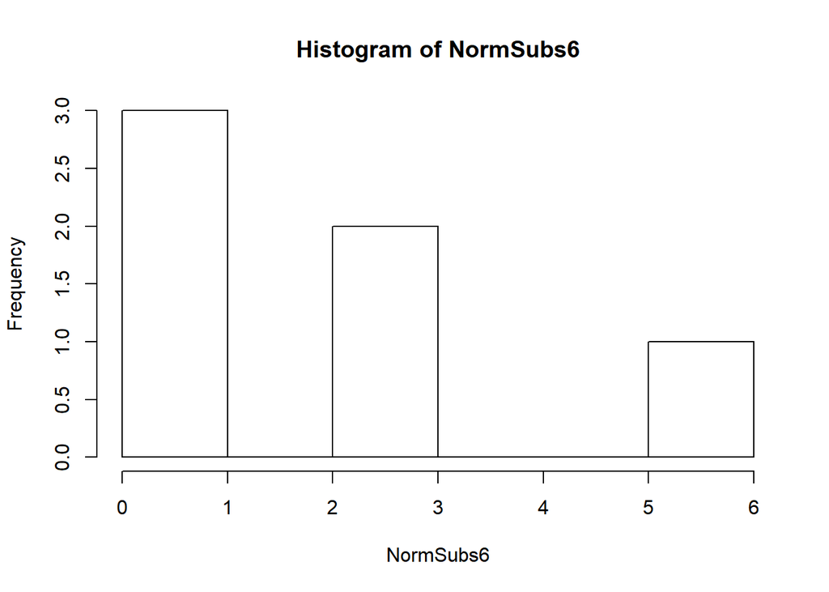

```r
hist(NormSubs6)
```

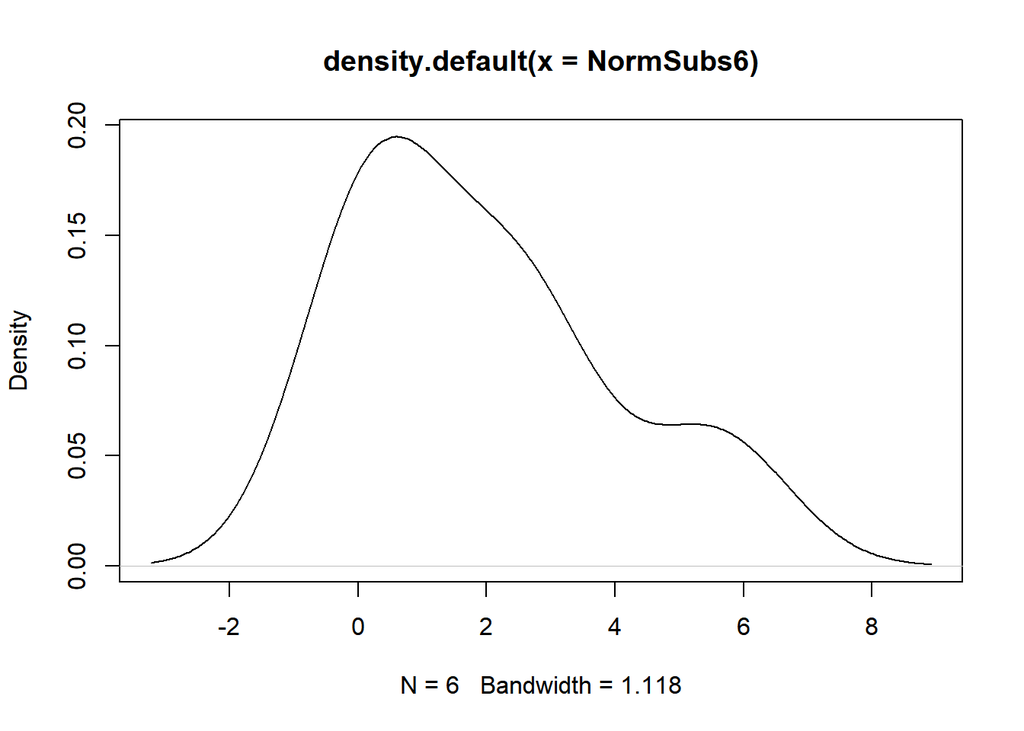

```r
plot(density(NormSubs6))
```

Student’s $t$:

```r
TSubs6<- xrt_n10000[1:6]
summary(TSubs6)
```

```
##     Min.  1st Qu.   Median     Mean  3rd Qu.     Max.
## -0.96300 -0.14891  0.03367  0.61769  1.06361  3.40464
```

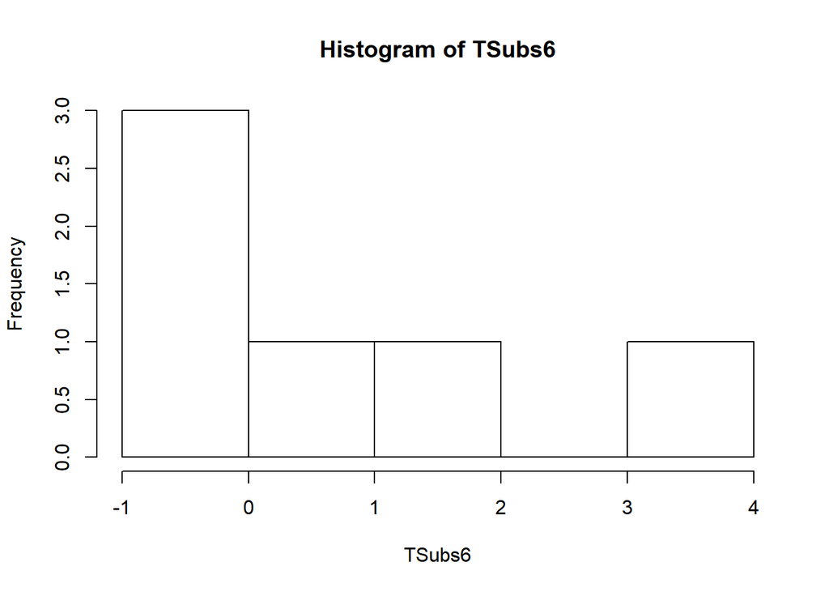

```r
hist(TSubs6)
```

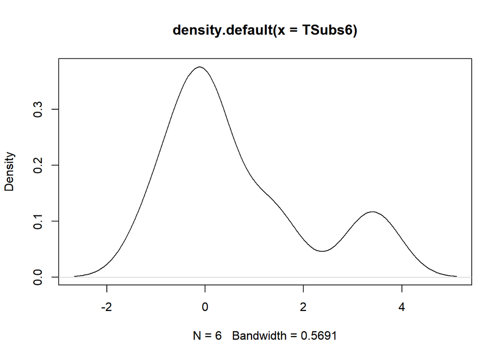

```r
plot(density(TSubs6))
```

$\chi ^ 2$ (Not normal)

```r
ChiSubs6<- xChi_n10000[1:6]
summary(ChiSubs6)
```

```
##    Min. 1st Qu.  Median    Mean 3rd Qu.    Max.
## 0.03434 0.19385 0.74322 0.72766 1.16498 1.52891
```

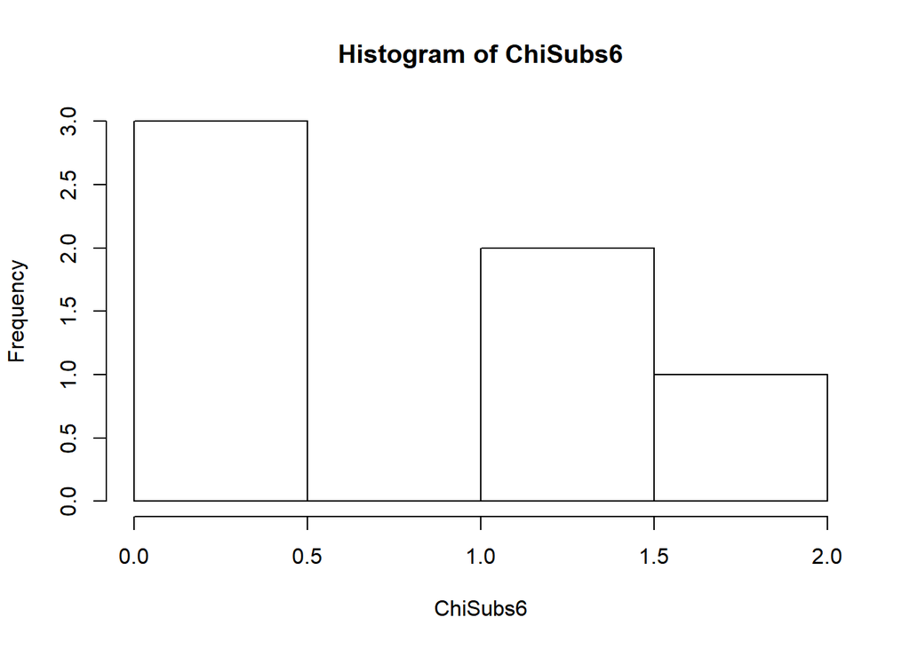

```r
hist(ChiSubs6)
```

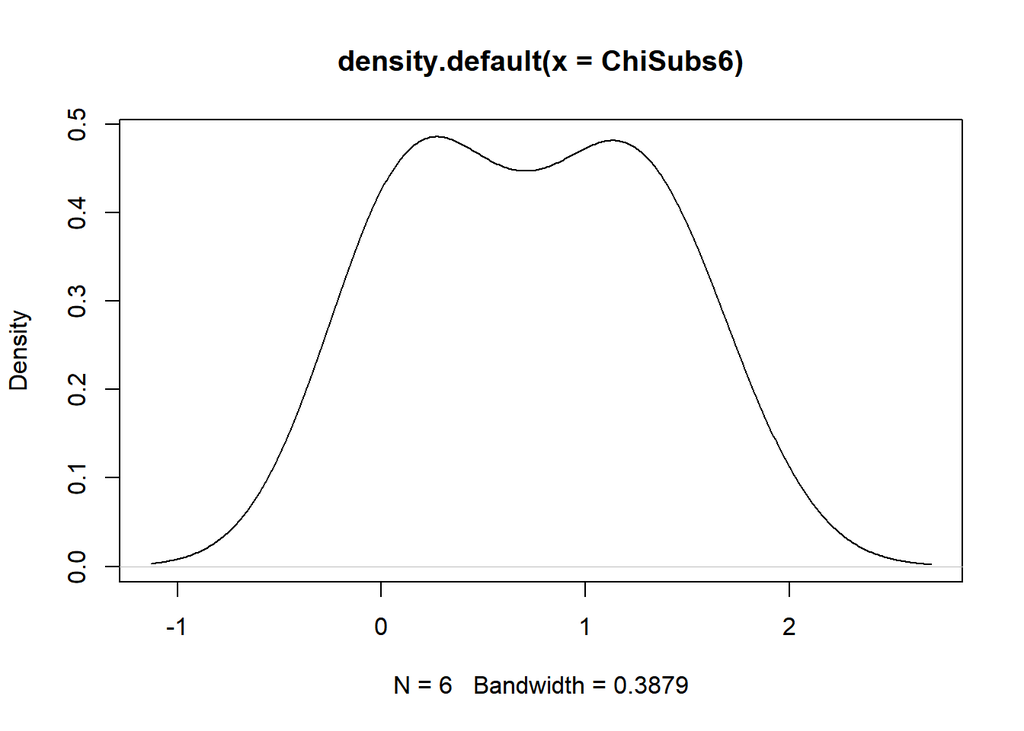

```r
plot(density(ChiSubs6))
```

$F$-Distribution

```r
FSubs6<- xFd_n10000[1:6]
summary(FSubs6)
```

```
##    Min. 1st Qu.  Median    Mean 3rd Qu.    Max.
##  0.5374  0.7094  1.1642  1.1845  1.3596  2.2585
```

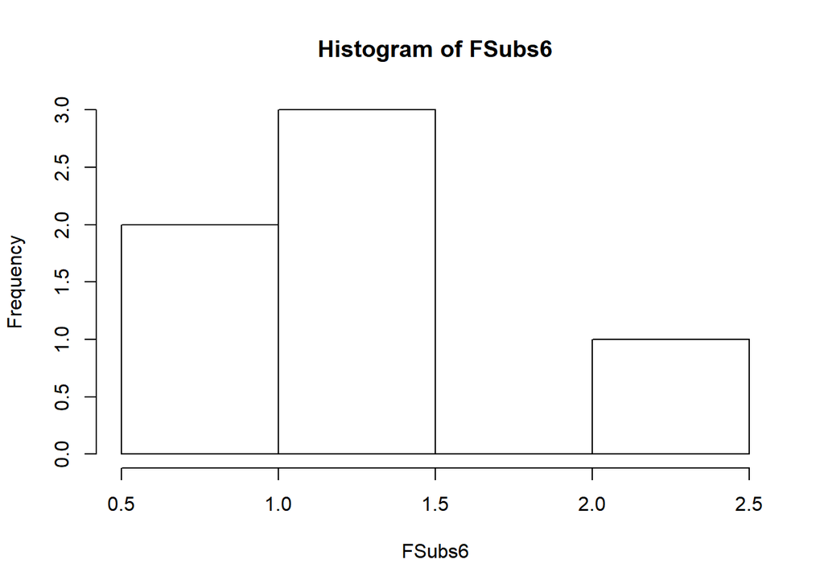

```r
hist(FSubs6)
```

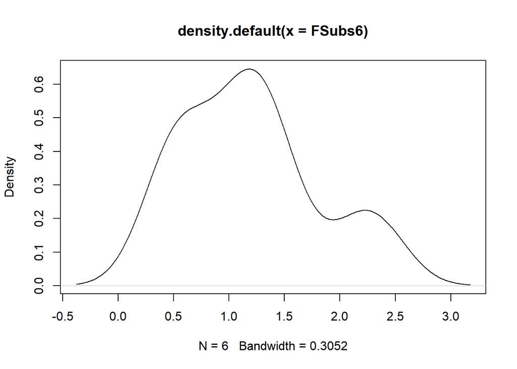

```r
plot(density(FSubs6))
```

Binomial

```r
BDSubs6<- xBD_n10000[1:6]
summary(BDSubs6)
```

```
##    Min. 1st Qu.  Median    Mean 3rd Qu.    Max.
##       4       5       6       6       7       8
```

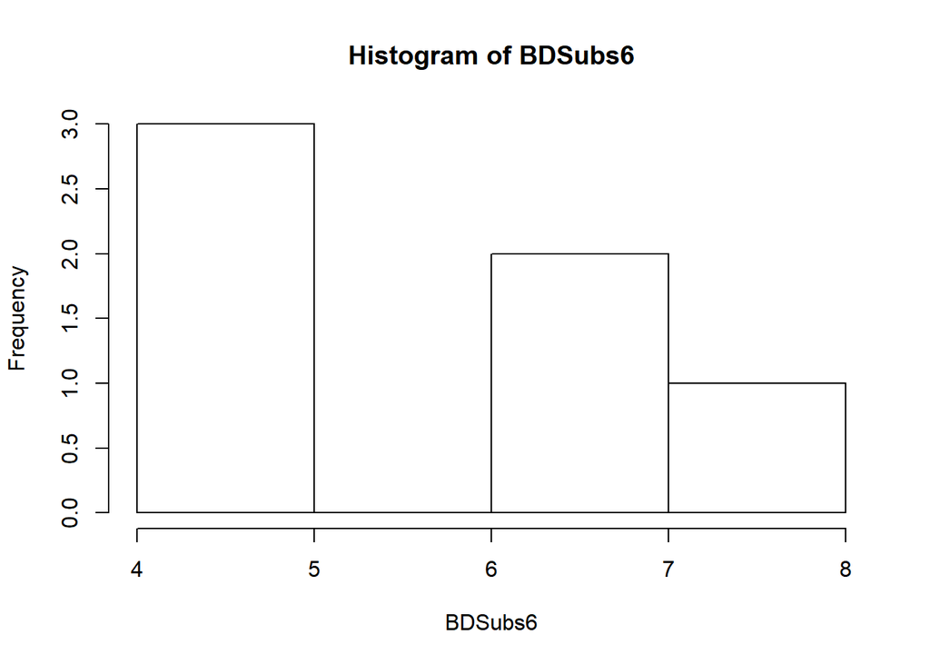

```r
hist(BDSubs6)
```

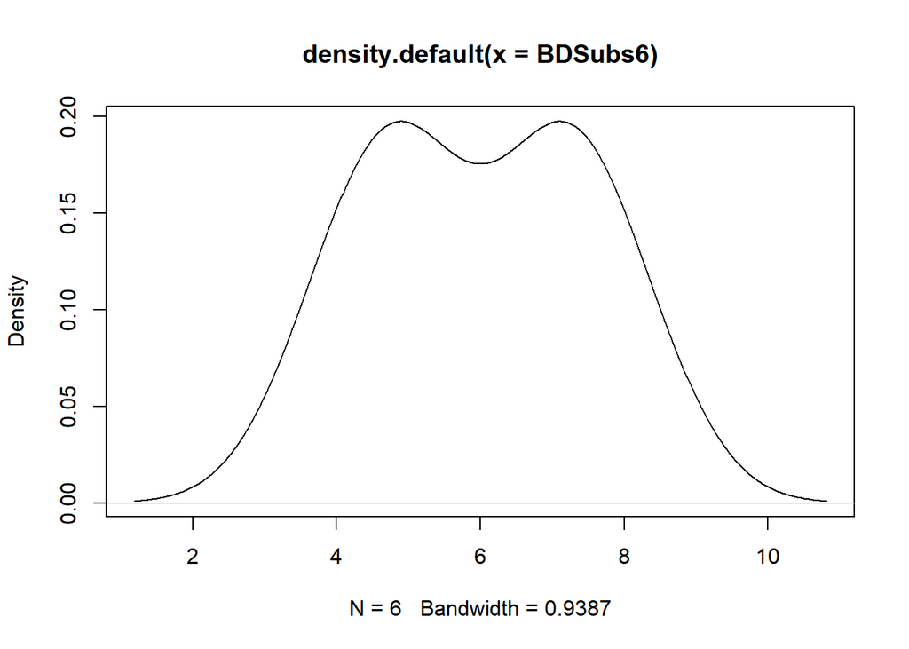

```r
plot(density(BDSubs6))
```

Negative binomial

```r
NegSubs6<- xNB_n10000[1:6]
summary(NegSubs6)
```

```
##    Min. 1st Qu.  Median    Mean 3rd Qu.    Max.
##    2.00    3.00    3.50    4.50    6.25    8.00
```

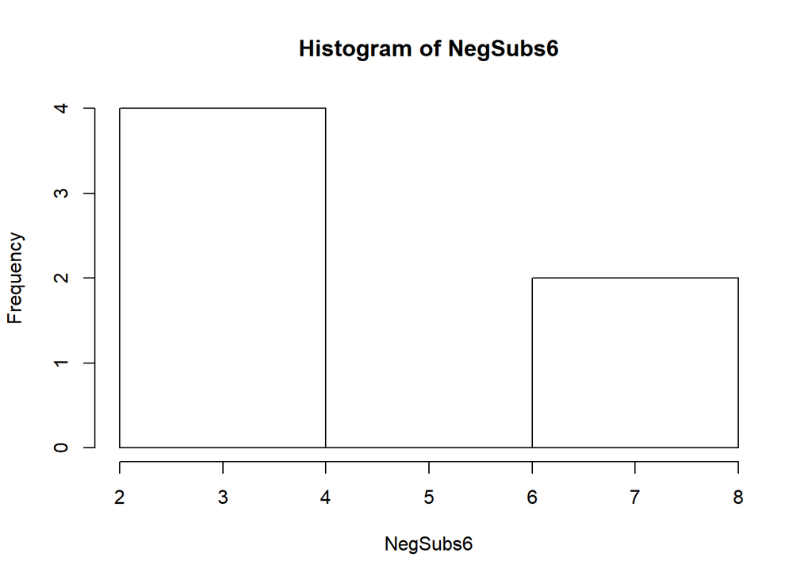

```r
hist(NegSubs6)
```

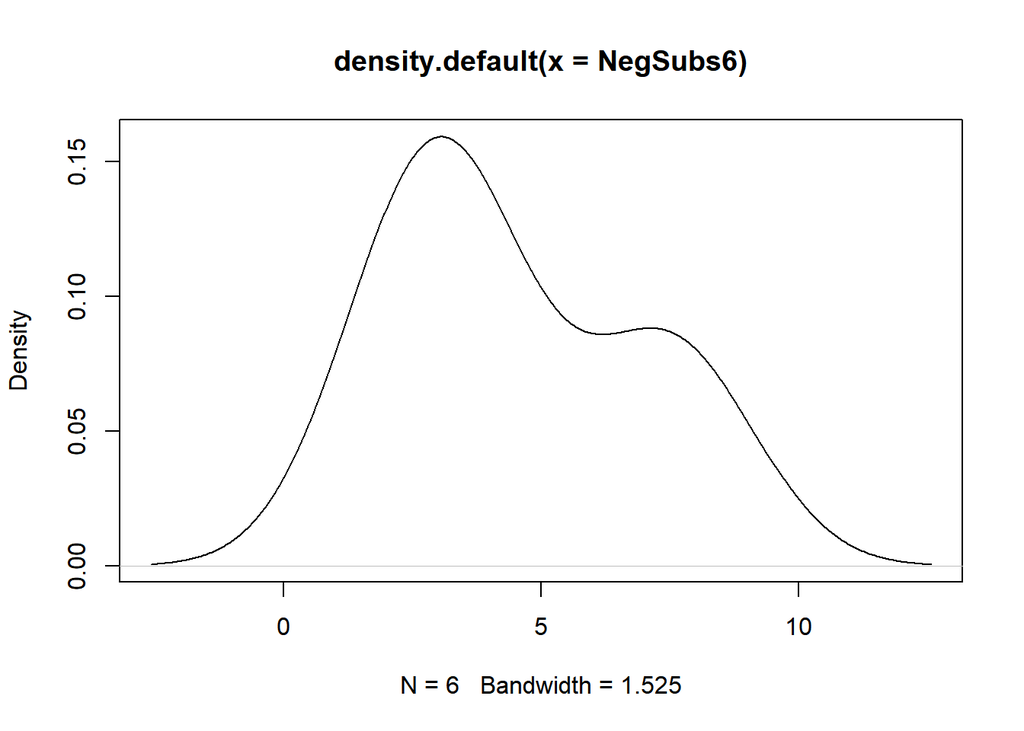

```r
plot(density(NegSubs6))
```

Poisson

```r
PoisSubs6<- xP_n10000[1:6]
summary(PoisSubs6)
```

```
##    Min. 1st Qu.  Median    Mean 3rd Qu.    Max.
##    1.00    1.25    2.00    3.00    3.50    8.00
```

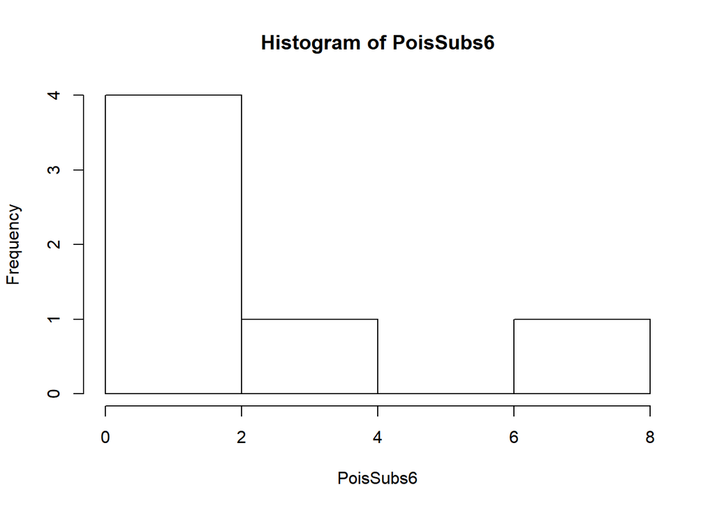

```r
hist(PoisSubs6)
```

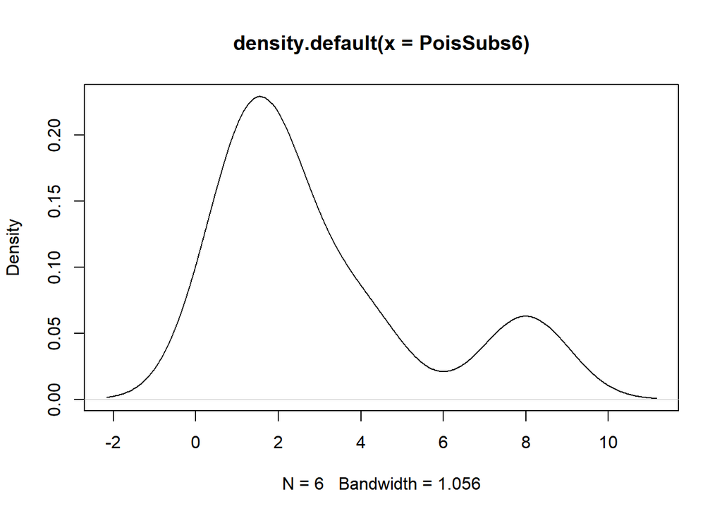

```r
plot(density(PoisSubs6))
```

### 3. Repeat Item 2 for the first $N = 10,\ 20,\ 30,\ \text{and}\ 50$ values from the random vector you generated in Item 1. Remark on the changing behaviour as the sample size increases.

Normal: as sample size increases, Normal distribution approaches Gaussian shape centered at the mean ($\mu = 2$):

```r
NormSubs10<- xNorm_n10000[1:10]
summary(NormSubs10)
```

```
##    Min. 1st Qu.  Median    Mean 3rd Qu.    Max.
##  0.1315  0.7787  2.5737  2.2956  3.2381  5.5672
```

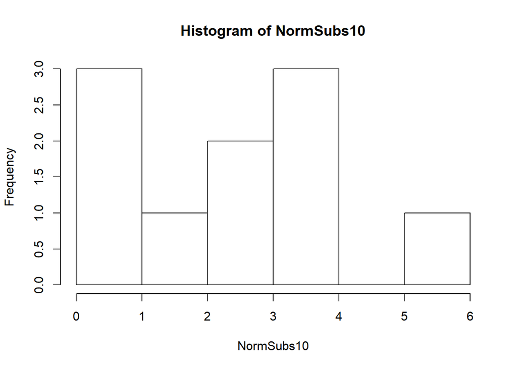

```r
hist(NormSubs10)
```

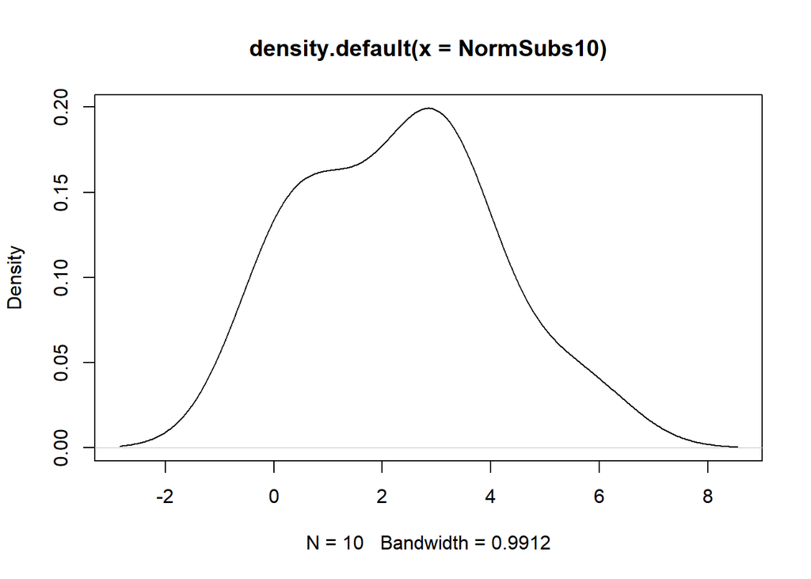

```r
plot(density(NormSubs10))
```

```r
NormSubs20<- xNorm_n10000[1:20]
summary(NormSubs20)
```

```
##    Min. 1st Qu.  Median    Mean 3rd Qu.    Max.
##  -2.952   1.141   2.804   2.426   3.697   5.567
```

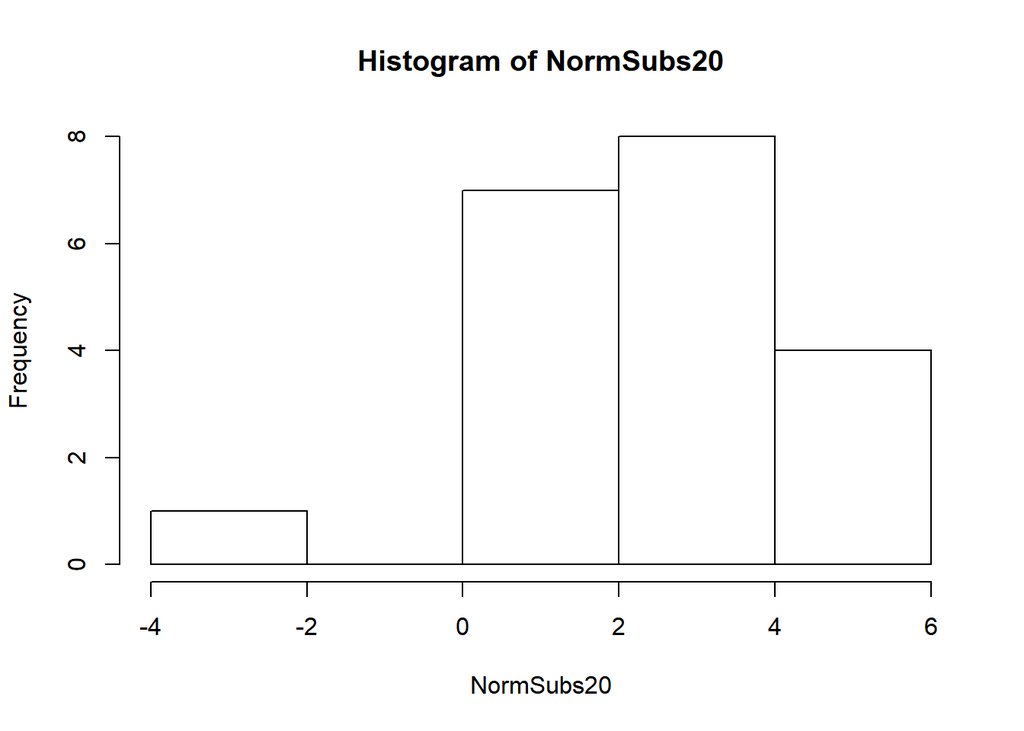

```r
hist(NormSubs20)
```

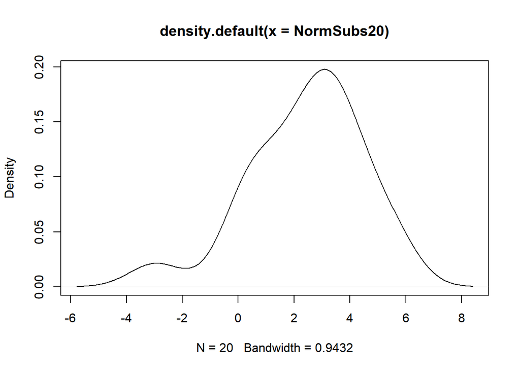

```r
plot(density(NormSubs20))
```

```r
NormSubs30<- xNorm_n10000[1:30]
summary(NormSubs30)
```

```
##    Min. 1st Qu.  Median    Mean 3rd Qu.    Max.
##  -2.952   1.027   2.574   2.184   3.585   5.567
```

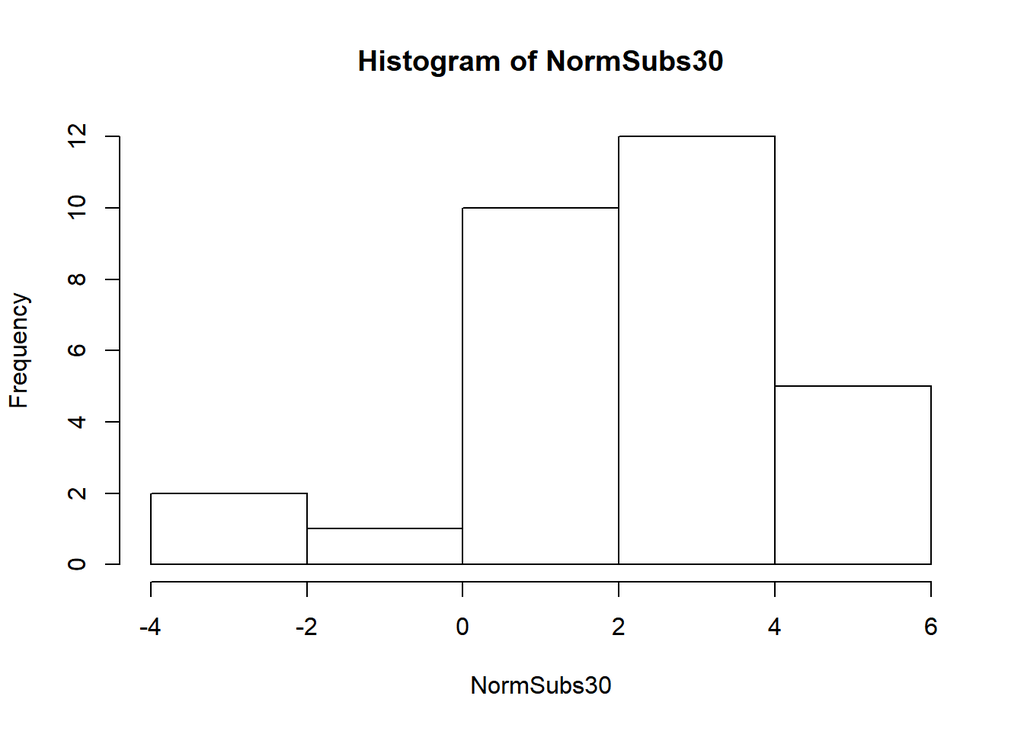

```r
hist(NormSubs30)
```

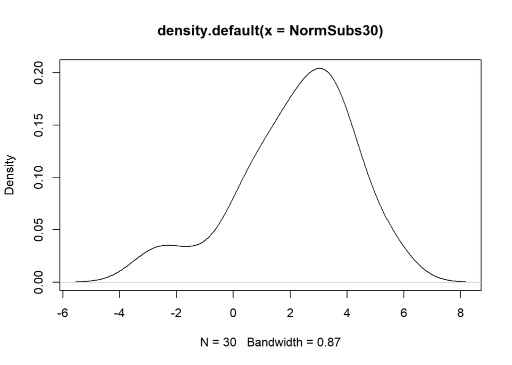

```r
plot(density(NormSubs30))
```

```r
NormSubs50<- xNorm_n10000[1:50]
summary(NormSubs50)
```

```
##    Min. 1st Qu.  Median    Mean 3rd Qu.    Max.
##  -2.952   1.168   2.289   2.225   3.628   5.567
```

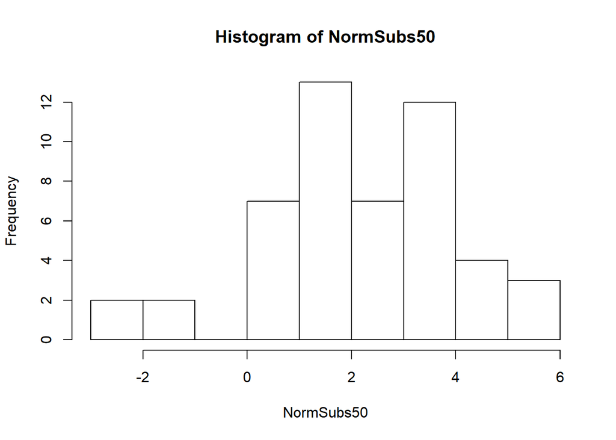

```r
hist(NormSubs50)
```

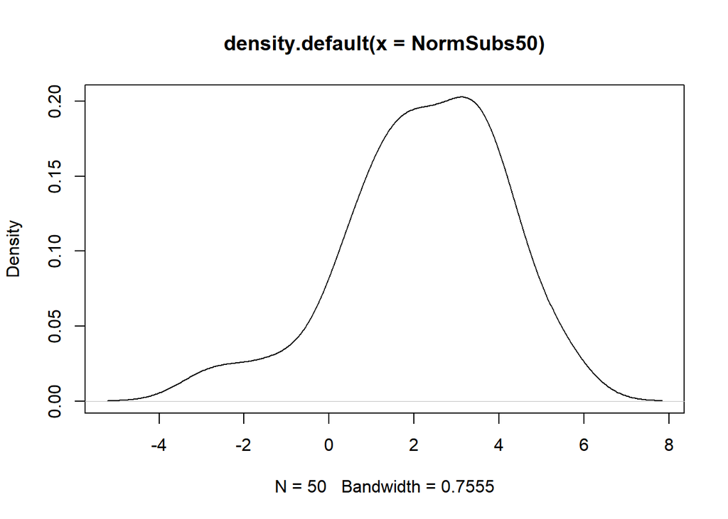

```r
plot(density(NormSubs50))
```

Student’s $t$: as sample size increases, the distribution shapes up as normal around mean ($\mu=0$):

```r
TSubs10<- xrt_n10000[1:10]
summary(TSubs10)
```

```
##    Min. 1st Qu.  Median    Mean 3rd Qu.    Max.
## -0.9630 -0.1489  0.5992  0.9656  1.2625  4.7326
```

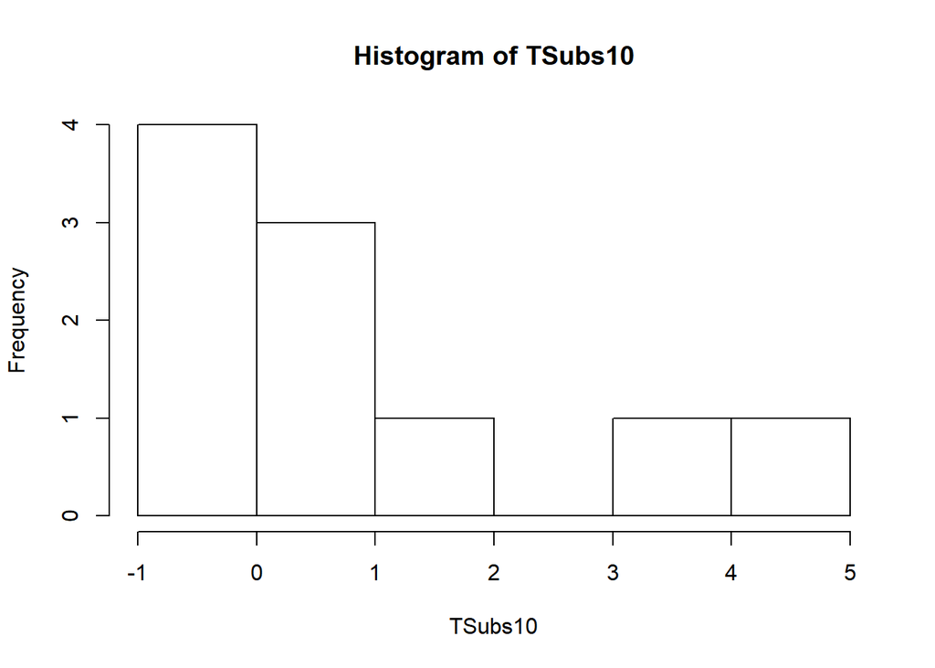

```r
hist(TSubs10)
```

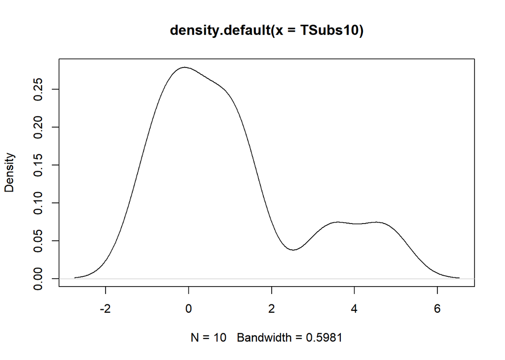

```r
plot(density(TSubs10))
```

```r
var(TSubs10)
```

```
## [1] 3.343344
```

```r
TSubs20<- xrt_n10000[1:20]
summary(TSubs20)
```

```
##    Min. 1st Qu.  Median    Mean 3rd Qu.    Max.
## -2.3694 -0.5698  0.2301  0.4317  1.0323  4.7326
```

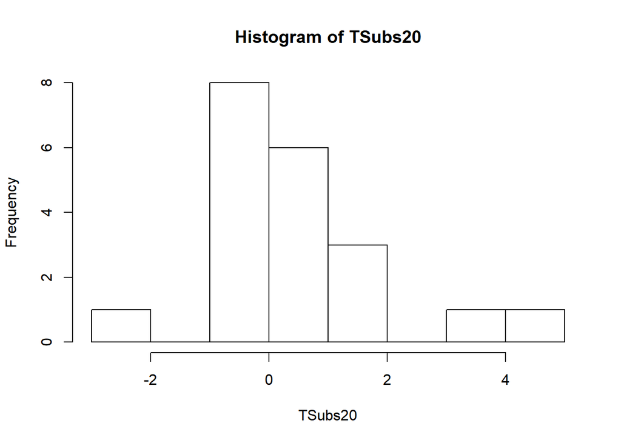

```r
hist(TSubs20)
```

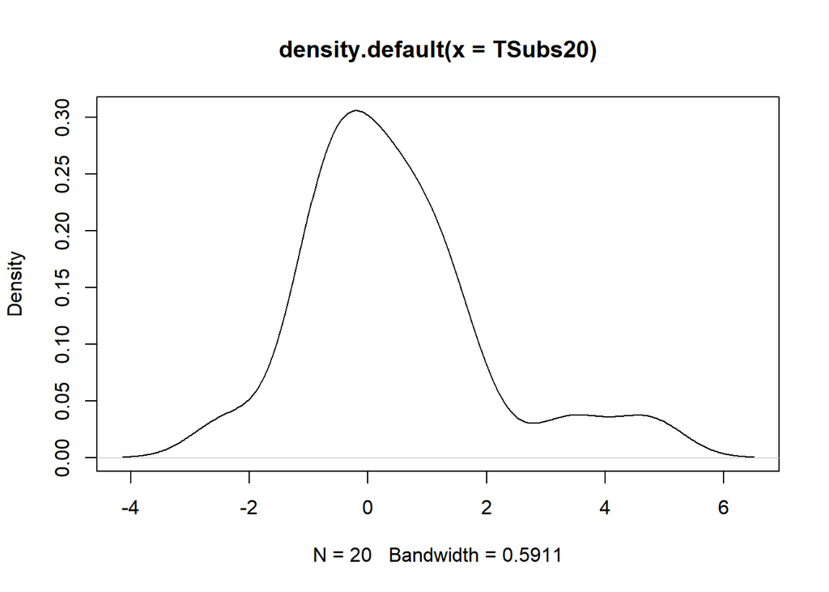

```r
plot(density(TSubs20))
```

```r
var(TSubs20)
```

```
## [1] 2.523075
```

```r
TSubs30<- xrt_n10000[1:30]
summary(TSubs30)
```

```
##     Min.  1st Qu.   Median     Mean  3rd Qu.     Max.
## -2.36936 -0.66960  0.03367  0.29728  1.09720  4.73264
```

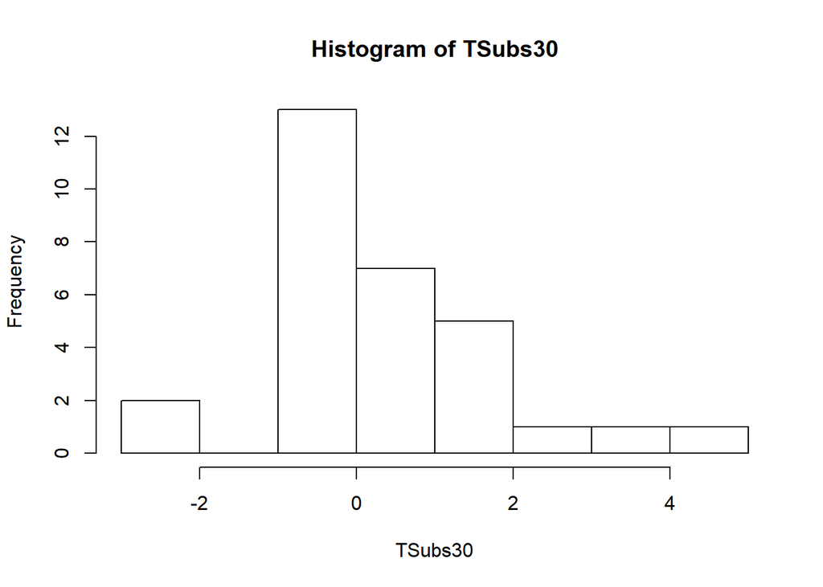

```r
hist(TSubs30)
```

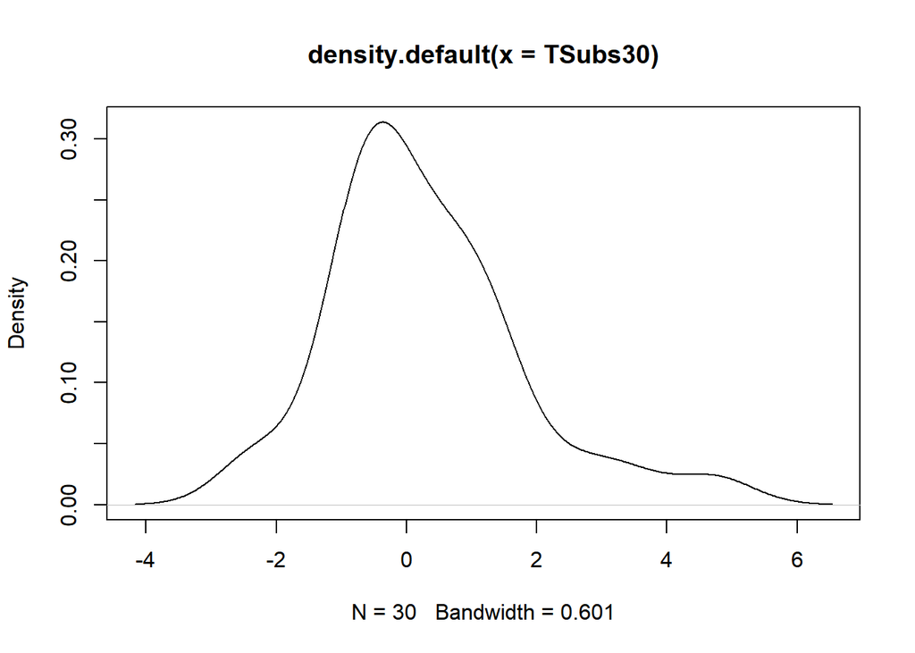

```r
plot(density(TSubs30))
```

```r
var(TSubs30)
```

```
## [1] 2.245901
```

```r
TSubs50<- xrt_n10000[1:50]
summary(TSubs50)
```

```
##    Min. 1st Qu.  Median    Mean 3rd Qu.    Max.
## -2.3694 -0.5108  0.2383  0.4470  1.3048  4.7326
```

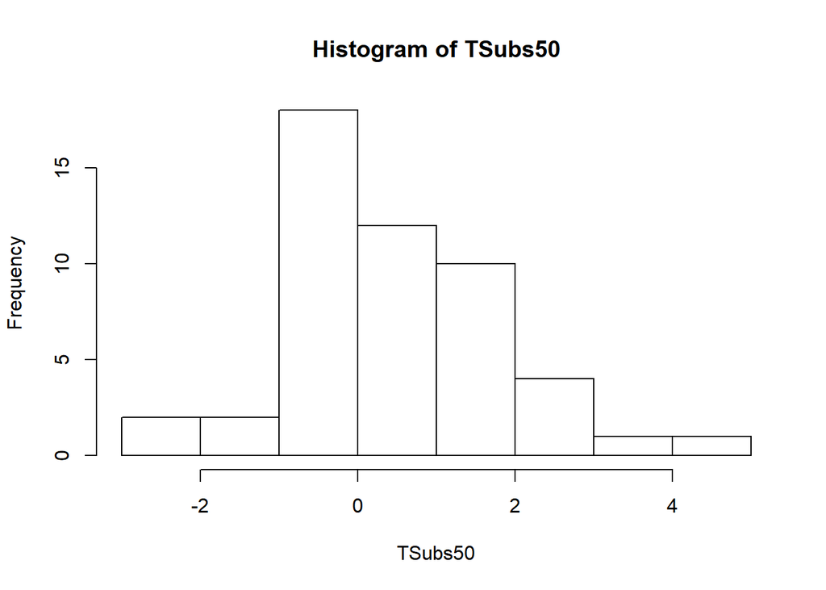

```r
hist(TSubs50)
```

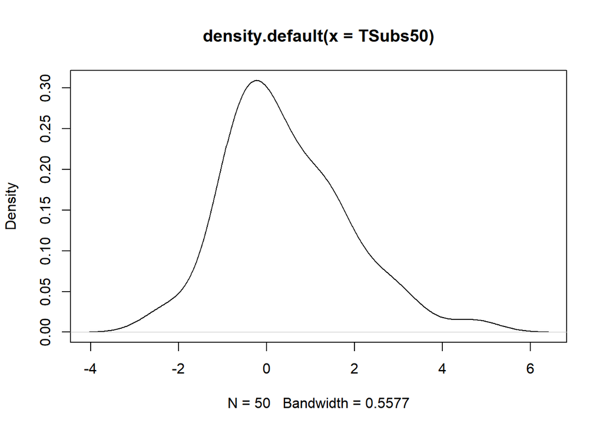

```r
plot(density(TSubs50))
```

```r
var(TSubs50)
```

```
## [1] 1.95557
```

$\chi ^ 2$: as sample size increases, the skeweness of the grapth is more accurtely defined.

```r
ChiSubs10<- xChi_n10000[1:10]
ChiSubs20<- xChi_n10000[1:20]
ChiSubs30<- xChi_n10000[1:30]
ChiSubs50<- xChi_n10000[1:50]

summary(ChiSubs10)
```

```
##    Min. 1st Qu.  Median    Mean 3rd Qu.    Max.
## 0.03434 0.37583 1.11595 1.51670 1.80707 5.75437
```